# Video Game Sales Preprocessing

Dangelo Feliciano, Anirudh Eswara

2026-05-06

## Setup

```r
library(tidyverse)
library(scales)
library(knitr)

source(here::here("R", "01_load_clean.R"))
```

## 1. Load Raw Data

```r
raw <- load_raw()
glimpse(raw)
```

```
## Rows: 16,719
## Columns: 16
## $ Name            <chr> "Wii Sports", "Super Mario Bros.", "Mario Kart Wii", "…
## $ Platform        <chr> "Wii", "NES", "Wii", "Wii", "GB", "GB", "DS", "Wii", "…
## $ Year_of_Release <chr> "2006", "1985", "2008", "2009", "1996", "1989", "2006"…
## $ Genre           <chr> "Sports", "Platform", "Racing", "Sports", "Role-Playin…
## $ Publisher       <chr> "Nintendo", "Nintendo", "Nintendo", "Nintendo", "Ninte…
## $ NA_Sales        <dbl> 41.36, 29.08, 15.68, 15.61, 11.27, 23.20, 11.28, 13.96…
## $ EU_Sales        <dbl> 28.96, 3.58, 12.76, 10.93, 8.89, 2.26, 9.14, 9.18, 6.9…
## $ JP_Sales        <dbl> 3.77, 6.81, 3.79, 3.28, 10.22, 4.22, 6.50, 2.93, 4.70,…
## $ Other_Sales     <dbl> 8.45, 0.77, 3.29, 2.95, 1.00, 0.58, 2.88, 2.84, 2.24, …
## $ Global_Sales    <dbl> 82.53, 40.24, 35.52, 32.77, 31.37, 30.26, 29.80, 28.92…
## $ Critic_Score    <dbl> 76, NA, 82, 80, NA, NA, 89, 58, 87, NA, NA, 91, NA, 80…
## $ Critic_Count    <dbl> 51, NA, 73, 73, NA, NA, 65, 41, 80, NA, NA, 64, NA, 63…
## $ User_Score      <chr> "8", NA, "8.3", "8", NA, NA, "8.5", "6.6", "8.4", NA, …
## $ User_Count      <dbl> 322, NA, 709, 192, NA, NA, 431, 129, 594, NA, NA, 464,…
## $ Developer       <chr> "Nintendo", NA, "Nintendo", "Nintendo", NA, NA, "Ninte…
## $ Rating          <chr> "E", NA, "E", "E", NA, NA, "E", "E", "E", NA, NA, "E",…
```

## 2. Missing Value Overview

```r
col_summary(raw) %>%
  arrange(desc(null_pct)) %>%
  kable(digits = 2, caption = "Missing Values — Raw Dataset")
```

Missing Values — Raw Dataset

| column | dtype | non_null | null_n | null_pct |
| --- | --- | --- | --- | --- |
| User_Count | numeric | 7590 | 9129 | 54.60 |
| Critic_Score | numeric | 8137 | 8582 | 51.33 |
| Critic_Count | numeric | 8137 | 8582 | 51.33 |
| Rating | character | 9950 | 6769 | 40.49 |
| User_Score | character | 10015 | 6704 | 40.10 |
| Developer | character | 10096 | 6623 | 39.61 |
| Year_of_Release | character | 16450 | 269 | 1.61 |
| Publisher | character | 16665 | 54 | 0.32 |
| Name | character | 16717 | 2 | 0.01 |
| Genre | character | 16717 | 2 | 0.01 |
| Platform | character | 16719 | 0 | 0.00 |
| NA_Sales | numeric | 16719 | 0 | 0.00 |
| EU_Sales | numeric | 16719 | 0 | 0.00 |
| JP_Sales | numeric | 16719 | 0 | 0.00 |
| Other_Sales | numeric | 16719 | 0 | 0.00 |
| Global_Sales | numeric | 16719 | 0 | 0.00 |

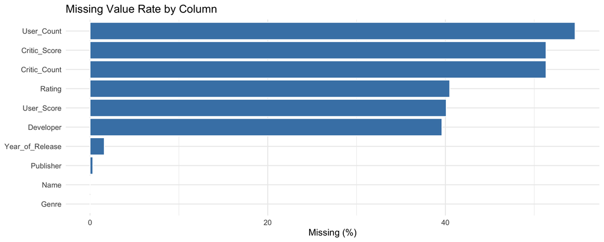

```r
col_summary(raw) %>%
  filter(null_pct > 0) %>%
  ggplot(aes(x = reorder(column, null_pct), y = null_pct)) +
  geom_col(fill = "steelblue", color = "white") +
  coord_flip() +
  labs(title = "Missing Value Rate by Column",
       x = NULL, y = "Missing (%)") +
  theme_minimal()
```

> **Observations:** - `Critic_Score`, `User_Score`, `Critic_Count`, `User_Count`, `Developer`, and `Rating` all have substantial missingness, these come from Metacritic and were not available for every title. - `Year_of_Release` and `Genre` have minor missingness. - Sales columns and `Name`/`Platform`/`Publisher` are nearly complete.

## 3. Cleaning Steps

### 3a. Remove Missing / Zero Target

We cannot model rows with no `Global_Sales` value.

```r
df <- raw %>% clean_target()
cat("Rows remaining:", nrow(df), "\n")
```

```
## Rows remaining: 16719
```

### 3b. Clean Year of Release

`Year_of_Release` is stored as character (some entries are `"N/A"`). We coerce to integer and drop implausible values outside 1980–2020.

```r
df <- df %>% clean_year()
cat("Year range:", range(df$Year_of_Release), "\n")
```

```
## Year range: 1980 2020
```

### 3c. Filter Valid Genres

Drop rows with missing or unrecognised genre values.

```r
df <- df %>% clean_genre()
cat("Genres present:", paste(sort(unique(df$Genre)), collapse = ", "), "\n")
```

```
## Genres present: Action, Adventure, Fighting, Misc, Platform, Puzzle, Racing, Role-Playing, Shooter, Simulation, Sports, Strategy
```

### 3d. Clean User Score

`User_Score` contains `"tbd"` strings where a score hasn’t been assigned yet. We replace these with `NA` and convert the column to numeric.

```r
df <- df %>% clean_user_score()

cat("User_Score — NA count after cleaning:",
    sum(is.na(df$User_Score)), "\n")
```

```
## User_Score — NA count after cleaning: 8985
```

### 3e. Standardise ESRB Rating

```r
df <- df %>% clean_rating()
df %>% count(Rating, sort = TRUE) %>% kable()
```

| Rating | n |
| --- | --- |
| Other | 6690 |
| E | 3922 |
| T | 2905 |
| M | 1536 |
| E10+ | 1393 |
| AO | 1 |
| RP | 1 |

## 4. Cleaned Dataset Summary

```r
cat("Shape after cleaning:", nrow(df), "rows x", ncol(df), "cols\n\n")
```

```
## Shape after cleaning: 16448 rows x 16 cols
```

```r
col_summary(df) %>%
  arrange(desc(null_pct)) %>%
  kable(digits = 2, caption = "Missing Values — After Cleaning")
```

Missing Values — After Cleaning

| column | dtype | non_null | null_n | null_pct |
| --- | --- | --- | --- | --- |
| User_Score | numeric | 7463 | 8985 | 54.63 |
| User_Count | numeric | 7463 | 8985 | 54.63 |
| Critic_Score | numeric | 7983 | 8465 | 51.47 |
| Critic_Count | numeric | 7983 | 8465 | 51.47 |
| Developer | character | 9907 | 6541 | 39.77 |
| Publisher | character | 16416 | 32 | 0.19 |
| Name | character | 16448 | 0 | 0.00 |
| Platform | character | 16448 | 0 | 0.00 |
| Year_of_Release | integer | 16448 | 0 | 0.00 |
| Genre | character | 16448 | 0 | 0.00 |
| NA_Sales | numeric | 16448 | 0 | 0.00 |
| EU_Sales | numeric | 16448 | 0 | 0.00 |
| JP_Sales | numeric | 16448 | 0 | 0.00 |
| Other_Sales | numeric | 16448 | 0 | 0.00 |
| Global_Sales | numeric | 16448 | 0 | 0.00 |
| Rating | factor | 16448 | 0 | 0.00 |

## 5. Stopping Point

The dataset is now clean through the missing value handling stage. Remaining steps to complete:

- **Feature engineering** — log-transform of `Global_Sales`, scaling `User_Score` to 0–100, decade variable, platform grouping
- **EDA** — distributions, genre/platform trends, score vs sales relationships
- **Regression modeling** — OLS with `Critic_Score`, `User_Score`, `Genre`, `Rating`, `Year_of_Release`

```r
write_csv(df, here::here("data", "vgsales_clean.csv"))
cat("Saved: data/vgsales_clean.csv\n")
```

```
## Saved: data/vgsales_clean.csv
```